# FP1

Kate Messitte

# Research questions: 1. How is repeated exposure to extremist content related to changes in the language and behavior of users over time 2. How do major political or social events affect online indicators associated with radicalization, such as perceived threat, out-group hostility, and engagement with extremist content? 3. Are people who engage with extremist content more likely to move into more extreme online communities over time?

```r
library(data.table)
incels_test <- fread(
  "~/Downloads/incels.is_AllComments.anon",
  sep = "\t",
  nrows = 1000
)

names(incels_test)
```

```
## [1] "link"             "comment_id"       "924978982.463397" "parent"
## [5] "timestamp"        "title"            "text"
```

```r
str(incels_test)
```

```
## Classes 'data.table' and 'data.frame':   1000 obs. of  7 variables:
##  $ link            : chr  "0-10-deformed-curry-with-micropenis-fuck-ultimate-11-10-stacy.478105 2.html" "0-10-deformed-curry-with-micropenis-fuck-ultimate-11-10-stacy.478105 2.html" "0-10-deformed-curry-with-micropenis-fuck-ultimate-11-10-stacy.478105 2.html" "0-10-deformed-curry-with-micropenis-…
##  $ comment_id      : chr  "post-11015920" "post-11015929" "post-11015932" "post-11015939" ...
##  $ 924978982.463397: num  9.25e+08 9.25e+08 9.25e+08 9.25e+08 9.25e+08 ...
##  $ parent          : chr  "" "" "" "" ...
##  $ timestamp       : int  1681672657 1681672779 1681672800 1681672859 1681672862 1681672904 1681672908 1681673768 1681674948 1681675953 ...
##  $ title           : chr  "NSFW 0/10 deformed curry with micropenis fuck ultimate 11/10 stacy" "" "" "" ...
##  $ text            : chr  "View: https://youtu.be/U65-R5UojX8" "Why are you making clickbait titles?" "i heard about that video before, he's just a degenerate cuck that should be killed, still can't believe why wou"| __truncated__ "" ...
##  - attr(*, ".internal.selfref")=<externalptr>
```

```r
summary(incels_test)
```

```
##      link            comment_id        924978982.463397       parent
##  Length:1000        Length:1000        Min.   :924979184   Length:1000
##  Class :character   Class :character   1st Qu.:924993451   Class :character
##  Mode  :character   Mode  :character   Median :925015113   Mode  :character
##                                        Mean   :925025104
##                                        3rd Qu.:925056366
##                                        Max.   :925114306
##    timestamp            title               text
##  Min.   :1.677e+09   Length:1000        Length:1000
##  1st Qu.:1.681e+09   Class :character   Class :character
##  Median :1.682e+09   Mode  :character   Mode  :character
##  Mean   :1.681e+09
##  3rd Qu.:1.682e+09
##  Max.   :1.683e+09
```

```r
table(incels_test$parent == "")
```

```
##
## FALSE  TRUE
##   514   486
```

```r
table(incels_test$title == "")
```

```
##
## FALSE  TRUE
##    45   955
```

```r
length(unique(incels_test$`924978982.463397`))
```

```
## [1] 273
```

```r
user_counts <- incels_test[, .N, by = `924978982.463397`]

summary(user_counts$N)
```

```
##    Min. 1st Qu.  Median    Mean 3rd Qu.    Max.
##   1.000   1.000   2.000   3.663   4.000  42.000
```

```r
head(user_counts[order(-N)], 20)
```

```
##     924978982.463397     N
##                <num> <int>
##  1:        924980978    42
##  2:        925070457    29
##  3:        925006724    22
##  4:        925063010    21
##  5:        924994112    19
##  6:        924992007    16
##  7:        924993451    16
##  8:        925009352    16
##  9:        924980184    15
## 10:        924992600    15
## 11:        925015729    15
## 12:        925085636    15
## 13:        924979788    13
## 14:        924982968    13
## 15:        924984924    12
## 16:        924985278    12
## 17:        925000869    12
## 18:        924996400    11
## 19:        925020738    11
## 20:        924984095    10
##     924978982.463397     N
##                <num> <int>
```

```r
incels <- fread(
  "~/Downloads/incels.is_AllComments.anon",
  sep = "\t"
)
```

```r
setnames(
  incels,
  old = "924978982.463397",
  new = "user"
)
```

```r
incels_clean <- incels[
  !is.na(text) & trimws(text) != ""
]
```

```r
sum(duplicated(incels_clean$text))
```

```
## [1] 1078044
```

```r
incels_clean <- unique(incels_clean)
```

```r
incels[, date := as.POSIXct(timestamp, origin = "1970-01-01", tz = "UTC")]

incels[, month := format(date, "%Y-%m")]

monthly_comments <- incels[
  !is.na(text) & trimws(text) != "",
  .N,
  by = month
]
```

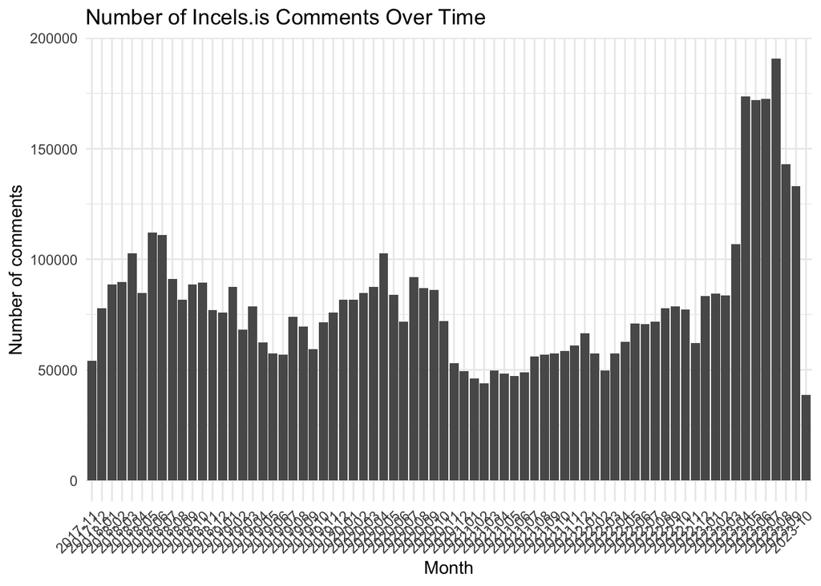

```r
library(ggplot2)

ggplot(monthly_comments, aes(x = month, y = N)) +
  geom_col() +
  labs(
    title = "Number of Incels.is Comments Over Time",
    x = "Month",
    y = "Number of comments"
  ) +
  theme_minimal() +
  theme(
    axis.text.x = element_text(angle = 45, hjust = 1)
  )
```

# DATASET 2 Stormfront posts

```r
library(readr)
StormfrontPosts <- read_csv("StormfrontPosts.csv")
View(StormfrontPosts)
```

###a) The dataset contains posts collected from Stormfront, an online discussion forum associated with white-supremacist and white-nationalist communities. The data were collected for research on online extremist language and behavior. User identities are anonymized in the dataset, so the identifier does not represent users’ actual names.

###b) The dataset represents people who participated in discussions on the Stormfront forum. Each row represents an individual post or piece of forum content. The dataset measures characteristics of online discussions, including information about the post, the anonymous user who created it, when it was posted, and the content of the post. Because the users are anonymous, the data can be used to examine patterns of participation and language without identifying individual people.

###c) One limitation is that the dataset only represents people who participated on Stormfront and should not be treated as representative of all people who hold extremist or white-supremacist beliefs. The users are also anonymous, so there is limited information about their demographic or personal characteristics. For example, the dataset may not provide information about users’ age, location, education, or other psychological characteristics. Another limitation is that the dataset measures what people posted online rather than directly measuring their psychological beliefs, attitudes, or behavior. A person’s language in an online forum does not necessarily tell us exactly what they believe or what they would do offline. The dataset is also historical, so it may not reflect how extremist communities communicate on the internet today.

###d) The dataset includes variables describing the posts and the users who made them. The anonymous user identifier is useful because it allows us to distinguish between users and examine how individual users participate in the forum without knowing their real identities. The post text is particularly useful for a psychology-focused project because it allows researchers to examine language, emotional content, hostility, or other characteristics of communication. The date or timestamp is also useful because it allows us to examine how posting behavior or language changes over time. Other variables describing the post, such as its location within a discussion or its relationship to other posts, can be useful for studying interactions between users and how conversations develop.

###e)

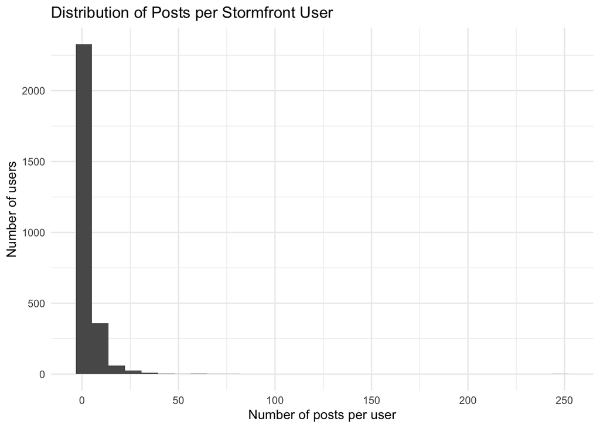

```r
library(data.table)
library(ggplot2)

# Load the Stormfront dataset
StormfrontPosts <- fread("StormfrontPosts.csv")

# Count the number of posts made by each anonymous user
user_counts <- StormfrontPosts[
  !is.na(user_id),
  .N,
  by = user_id
]

# Plot the distribution of posts per user
ggplot(user_counts, aes(x = N)) +
  geom_histogram(bins = 30) +
  labs(
    title = "Distribution of Posts per Stormfront User",
    x = "Number of posts per user",
    y = "Number of users"
  ) +
  theme_minimal()
```